# ВВЕДЕНИЕ

Для отбора признаков нам понадобится обучающая выборка. Для примера был взят [датасет](https://bigml.com/user/francisco/gallery/dataset/5163ad540c0b5e5b22000383) по оттоку клиентов телеком-оператора. Объекты данного датасета - это **клиенты**, а признаки следующие:

| Название признака | **Описание** |
| --- | --- |
| State | Буквенный код штата |
| Account length | Как долго клиент обслуживается компанией |
| Area code | Префикс номера телефона |
| International plan | Международный роуминг (подключен/не подключен) |
| Voice mail plan | Голосовая почта (подключена/не подключена) |
| Number vmail messages | Количество голосовых сообщений |
| Total day minutes | Общая длительность разговоров днем |
| Total day calls | Общее количество звонков днем |
| Total day charge | Общая сумма оплаты за услуги днем |
| Total eve minutes | Общая длительность разговоров вечером |
| Total eve calls | Общее количество звонков вечером |
| Total eve charge | Общая сумма оплаты за услуги вечером |
| Total night minutes | Общая длительность разговоров ночью |
| Total night calls | Общее количество звонков ночью |
| Total night charge | Общая сумма оплаты за услуги ночью |
| Total intl minutes | Общая длительность международных разговоров |
| Total intl calls | Общее количество международных разговоров |
| Total intl charge | Общая сумма оплаты за международные разговоры |
| Customer service calls | Число обращений в сервисный центр |
| Churn | Признак оттока клиента ( 1 - клиент ушелб, 0 - остался) |

**ЧТО ВООБЩЕ НУЖНО:**

По данному датасету необходимо обучить модель, которая будет хорошо предсказывать отток клиента по его признакам (т.е это задача классификации). Но поскольку, **СКОРЕЕ ВСЕГО**, не все признаки являются хорошими ( если признак плохой, то он будет снижать качество классификатора), необходимо отобрать те признаки, которые являются "хорошими", тем самым вполне возможно нам удастся повысить качество классификатора. Именно для отбора "хороших" признаков среди имеющихся признаков и используется метод Add.

**ПСЕВДОКОД АЛГОРИТМА:**

INPUT:  
$\mathscr{F}$ - все признаки  
$X^L$ - выборка  
$Q$ - критерий  
$d$ - параметр

$1. \mathscr{G}_0 = 0$  
2. для всех $j = 1,2,...,n, где j $ — сложность наборов:

1. найти признак, наиболее выгодный для добавления:  
   $ f^* = arg_{f \in \mathscr{F} \backslash \mathscr{G}_{j-1}} min Q(\mathscr{G}_{j-1} \cup f)$
2. добавить этот признак в набор  
   $ \mathscr{G}_{j} = \mathscr{G}_{j-1} \cup f^*$
3. запомнить, какую сложность имел самый лучший набор признаков  
   $ j^* = arg_{s:s \le j} \min Q(\mathscr{G}_{s}) $
4. <font color = 'blue'> если </font> $j - j^* \ge d$ <font color = 'blue'> то вернуть </font> $\mathscr{G}_{j^*}$

## ЗАГРУЗКА И ПРЕДОБРАБОТКА ДАТАСЕТА

```python
import pandas as pd #c помощью библиотеки Pandas табличные данные очень удобно загружать, обрабатывать
                    #и анализировать с помощью SQL-подобных запросов.
import numpy as np  # либа для быстрых вычислений
df = pd.read_csv('telecom_churn.csv')
df.head(5) # покажет первые 5 строчек датасета
```

|  | State | Account length | Area code | International plan | Voice mail plan | Number vmail messages | Total day minutes | Total day calls | Total day charge | Total eve minutes | Total eve calls | Total eve charge | Total night minutes | Total night calls | Total night charge | Total intl minutes | Total intl calls | Total intl charge | Customer service calls | Churn |
| --- | --- | --- | --- | --- | --- | --- | --- | --- | --- | --- | --- | --- | --- | --- | --- | --- | --- | --- | --- | --- |
| 0 | KS | 128 | 415 | No | Yes | 25 | 265.1 | 110 | 45.07 | 197.4 | 99 | 16.78 | 244.7 | 91 | 11.01 | 10.0 | 3 | 2.70 | 1 | False |
| 1 | OH | 107 | 415 | No | Yes | 26 | 161.6 | 123 | 27.47 | 195.5 | 103 | 16.62 | 254.4 | 103 | 11.45 | 13.7 | 3 | 3.70 | 1 | False |
| 2 | NJ | 137 | 415 | No | No | 0 | 243.4 | 114 | 41.38 | 121.2 | 110 | 10.30 | 162.6 | 104 | 7.32 | 12.2 | 5 | 3.29 | 0 | False |
| 3 | OH | 84 | 408 | Yes | No | 0 | 299.4 | 71 | 50.90 | 61.9 | 88 | 5.26 | 196.9 | 89 | 8.86 | 6.6 | 7 | 1.78 | 2 | False |
| 4 | OK | 75 | 415 | Yes | No | 0 | 166.7 | 113 | 28.34 | 148.3 | 122 | 12.61 | 186.9 | 121 | 8.41 | 10.1 | 3 | 2.73 | 3 | False |

```python
df.drop(columns='State', inplace=True) # удаляем столбец (признак) State, поскольку в нем достаточно много уникальных
                                    # значений и с этим непонятно, что делать, а выполнение one-hot encoding даст очень много
                                    # новых признаков
mapping = {"Yes": 1, "No":0}
df['International plan'] = df['International plan'].map(mapping) # заменяем "Yes" на 1, а "No" на 0
df['Voice mail plan'] = df['Voice mail plan'].map(mapping) # --//--
df['Churn'] = df['Churn'].astype(dtype='int') # True -> 1, False -> 0
```

```python
df.head(5)
```

|  | Account length | Area code | International plan | Voice mail plan | Number vmail messages | Total day minutes | Total day calls | Total day charge | Total eve minutes | Total eve calls | Total eve charge | Total night minutes | Total night calls | Total night charge | Total intl minutes | Total intl calls | Total intl charge | Customer service calls | Churn |
| --- | --- | --- | --- | --- | --- | --- | --- | --- | --- | --- | --- | --- | --- | --- | --- | --- | --- | --- | --- |
| 0 | 128 | 415 | 0 | 1 | 25 | 265.1 | 110 | 45.07 | 197.4 | 99 | 16.78 | 244.7 | 91 | 11.01 | 10.0 | 3 | 2.70 | 1 | 0 |
| 1 | 107 | 415 | 0 | 1 | 26 | 161.6 | 123 | 27.47 | 195.5 | 103 | 16.62 | 254.4 | 103 | 11.45 | 13.7 | 3 | 3.70 | 1 | 0 |
| 2 | 137 | 415 | 0 | 0 | 0 | 243.4 | 114 | 41.38 | 121.2 | 110 | 10.30 | 162.6 | 104 | 7.32 | 12.2 | 5 | 3.29 | 0 | 0 |
| 3 | 84 | 408 | 1 | 0 | 0 | 299.4 | 71 | 50.90 | 61.9 | 88 | 5.26 | 196.9 | 89 | 8.86 | 6.6 | 7 | 1.78 | 2 | 0 |
| 4 | 75 | 415 | 1 | 0 | 0 | 166.7 | 113 | 28.34 | 148.3 | 122 | 12.61 | 186.9 | 121 | 8.41 | 10.1 | 3 | 2.73 | 3 | 0 |

## Нам нужно еще ....

Теперь датасет чуть-чуть предобработан и можно пробовать , казалось бы, реализовывать алгоритм **Add**.Но нам для реализации алгоритма **Add** нужно взять еще модель, на которой мы будем экспериментировать и функцию потерь(loss function) для внешнего критерия Q.

**МОДЕЛЬ(КЛАССИФИКАТОР):**
Была взята модель логистической регрессии по одной простой причине. Логистическая регрессия является очень популярной на практике из-за своей ПРОСТОТЫ РЕАЛИЗАЦИИ (это по сути линейный классификатор с навешенной сигмоидой) и КАЧЕСТВА (очень хорошо работает). Если захочешь почитать про логистическую регрессию, то можно вот [здесь](https://habr.com/company/ods/blog/323890/)
**ФУНКЦИЯ ПОТЕРЬ:** Для задачи бинарной классификации в настоящее время пользуются логистической функцией потерь (log loss). Иногда ее называют кросэнтропийной функцией потерь (cross - entropy error function). $$Q_{ext}(\mu, X^{L}) = Q_{ext}(\mu (X^{l}), X^{k}) = \frac{1}{k} \sum\limits_{i = 1}^{k} \mathscr{L} (a(x^{(i)}), y^{(i)})$$ , где $ y^{(i)}$- истинная метка класса для объекта $ x^{(i)}$ (для случая бинарной классификации 0 или 1)
$ a(x^{(i)}) $ - предсказание алгоритма
$\mathscr{L} (a(x^{(i)}), y^{(i)}) = -y^{(i)}\log(a(x^{(i)})) - (1- y^{(i)}) \log(1 - a(x^{(i)}))$ - log loss функция потерь

# Реализация алгоритма Add

```python
#импортируем необходимые функции
from sklearn.linear_model import LogisticRegression #  LogisticRegression - класс для построения логистической регрессии
from sklearn.model_selection import train_test_split # train_test_split - функция, которая разбивает всю выборку на
                                                    # тестовую(контрольную) и обучающую в заданном соотношении
from matplotlib import pyplot as plt
import seaborn as sns
```

```python
def cross_entropy_cost(y_pred, y_true):
    """
        Данная функция реализует вычисление значения внешнего критерия для тестовой выборки X_k

        Arguments:
        y_pred - предсказание модели (В случае логистической - вероятности принадлежности объектов к 1 классу)
        y_true - для метки классов

    """
    k = y_pred.shape[0] #количество объектов
    # это может быть трудновато для понимания. Здесь используется  техника broadcasting, позволяющая складывать матрицы разных
    # размеров, к вектору прибавлять число и тп.
    # Например, запись 1 - [2,4,1,5,4] равносильна [1-2, 1-4, 1-1, 1-5, 1-4]
    return np.sum(- y_true*np.log(y_pred) - (1 - y_true)*np.log(1-y_pred))/k
```

```python
def get_best_feature(F, G, model, X_L_splitted):
    """
        Данная функция реализует поиск признака наиболее выгодного для добавления к списку G

        Arguments:

        Type          Name         Description
        list          G -          список уже ранее отобранных "хороших" признаков
        list          X_L_splitted список из следующих элементов (по порядку):
                                                    X_l - обучающую выборка
                                                    X_k - тестовая выборка
                                                    y_l - метки классов для X_l
                                                    y_k - метки классов для X_k
        list          F -          список признаков, из которых нужно выбрать оптимальный
                      model -      модель(классификатор), для которой(-го) осуществляется поиск информативных признаков

        Returns - список f_best из двух элементов: f_best[0] - оптимальный для добавления признак
                                                   f_best[1] - нижняя огибающая критерия для модели текущей сложности
    """
    X_l, X_k, y_l, y_k = X_L_splitted # равносильно следующему: X_l = X_L_splitted[0], X_k = X_L_splitted[1] и тд., но намного короче
    f_best = [-1,20000] ; # оптимальный признак и его значение внешнего критерия на текущем шаге алгоритма (временный список)
    for feature in F:
        G_plus_feature = list(G)
        G_plus_feature.append(feature) # аналогично операции G_(j−1) ∪ f с шага 3

        model.fit(X_l[G_plus_feature],y_l) # обучение модели
        y_predict = model.predict_proba(X_k[G_plus_feature]) #классификация объектов тестовой выборки с помощью обученой модели
        cost = cross_entropy_cost(y_predict[:,1],y_k) # вычисление Q (G_(j−1) ∪ f)
        if cost < f_best[1]:
            f_best[0] = feature;
            f_best[1] = cost;
    return f_best; # f*
```

```python
def plot_curve(costs):
    """
        Данная функция осуществляет построение огибающей кривой

        Arguments:
        Type    Name     Description
        list    costs -  список значений внешнего критерия
    """
    sns.set(); # чтобы красиво было
    plt.rcParams['figure.figsize'] = 15,8
    plt.plot(range(1,len(costs) + 1),costs, marker = '.', ms = 15, ls = '--');
    plt.title("Нижняя огибающая критерия", fontsize = 18)
    plt.xlabel("Сложность модели,j ", fontsize = 18)
    plt.ylabel("$ Q(j) = \min_{\mathscr{F} : |\mathscr{F}| = j} Q (\mathscr{F}) $", fontsize = 16)
    plt.xticks(size = 12)
    plt.yticks(size = 12)
    plt.xlim(1,len(costs))
    plt.ylim(np.min(costs) - 0.01, np.max(costs) + 0.01)
    idx_min = np.argmin(costs)
    plt.axvline(x = idx_min + 1, ymax = 0.01/(np.max(costs) - np.min(costs) + 0.02), color='red', )
    plt.axhline(y = costs[idx_min], xmax = (idx_min + 1 - 1)/(len(costs) - 1), color='red')
    plt.show();
```

```python
def Add(X_L, Y, F, model, d =2, is_plot_curve = False):
    """
        Данная функция реализует алгоритм Add поиска информативных признаков

        Arguments:

        Type          Name        Description
        DataFrame     X_L -       выборка (целиком = test + train)
        np.array      Y -         метки классов для каждого объекта выборки (Y = {0,1})
        list          F -         список признаков, которыми описываются объекты
        int           d -         параметр, определяющий глубину просматривания вперед (по умолчанию равен 2)
                      model -     модель(классификатор), для которой(-го) осуществляется поиск информативных признаков
        bool          plot_curve- флаг принимает True, если необходимо построить нижнюю огибающую критерия (по умолчанию равен False)
        Returns - список оптимальных признаков
    """
    X_L_splitted = train_test_split(X_L, Y, test_size = 0.3, random_state = 42) # разбиение выборки на тестовую и обучающую
    j_best = -1;   # оптимальная сложность модели
    G = list();    # сюда будем записывать признаки оптимальные на каждом шаге алгоритма (вначале он пустой G_0 = 0)
    costs = list() # сюда будем записывать значения внешнего критерия
    n = len(F)     # количество признаков
    for j in range(1,n+1): # Реализация "для всех  j=1,2,...,n,где j  — сложность наборов"

        f_best = get_best_feature(F, G, model, X_L_splitted) # f* = arg min Q( G_(j−1) ∪ f)
        #добавление признака в список оптимальных
        G.append(f_best[0]); # G_j = G_(j-1) ∪ f*
        costs.append(f_best[1])
        del F[F.index(f_best[0])]; # удаление признака f_best из списка F. Код F.index(f_best[0]) возвращает индекс элемента
        # f_best[0] в списке F

        # Сначала приводим список (list) к нампаевскому массиву, чтобы потом воспользоваться встроенной функцией поиска
        # минимального элемента, но поскольку индексация в массиве начинается с 0, а сложность модели с 1, то найденный
        # индекс на 1 меньше сложности модели. Поэтому оптим. сложность модели = "оптим. индекс" + 1
        j_best = np.argmin(np.array(costs)) + 1 # j* = arg min Q(G_s) для s<=j

        if (j - j_best) > d:
            #plt.plot(range(1,j+1),costs, marker = '.', ms = 15, ls = '--');
            #plt.show();
            if is_plot_curve:
                plot_curve(costs)
            return G[:j_best];
    plt.plot(range(1, j + 1), costs,  marker = '.', ms = 15, ls = '--')
    plt.show();
    return G;
```

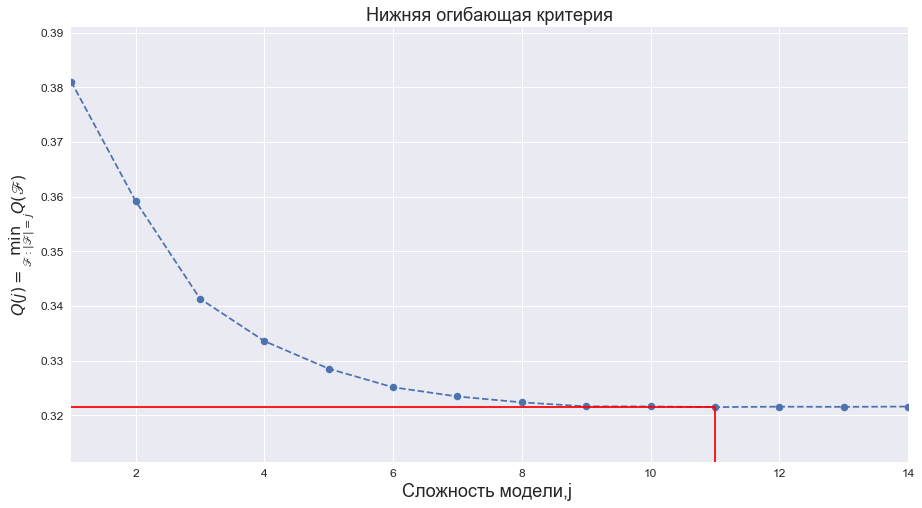

```
['Total day charge',
 'Customer service calls',
 'International plan',
 'Voice mail plan',
 'Total eve charge',
 'Area code',
 'Total intl calls',
 'Total night minutes',
 'Number vmail messages',
 'Total day minutes',
 'Total intl minutes']
```

```python
model = LogisticRegression()
X = df.iloc[:,:-1]
Y = df.iloc[:,-1]
Add(X, Y, list(df.columns[:-1]),model, 2, True)
```